# The Development of Color Terms in Shipibo-Konibo Children

Danielle Kellier*, Martin Fortier*, Maria Fernández Flecha, and Michael C. Frank

2018-11-13

### Study 1

Results and Discussion

All participants described at least 1 chip with the following set of color terms: light/white (“joxo”), dark/black (“wiso”), yellow (“panshin”), red (“joshin”), and green/blue (“yankon”). Most (79%) participants also used described at least 1 chip as faded or “manxan”, referring to a chip’s saturation. In terms of overall popularity, participants on average described 32% of chips as “yankon” (*SD* = 10%) followed by “joshin” (*M* = 12%, *SD* = 6%), “joxo” (10%, 5%), “panshin” (9%, 4%), “manxan” (7%, 7%), and “wiso” (6%, 4%).

**Nature of terms used**

Participants on average described 69% of chips using a SK-language basic color term like “yankon” (*SD* = 22%). Some participants described chips using SK-language ad hoc color terms, such as “nai” or *sky* for blue chips (*M* = 11%, *SD* = 12%), or ad hoc terms referring to saturation or luminosity of a chip, such as “manxan” (*M* = 7%, *SD* = 7%). Virtually all instances where a participant responded in Spanish involved a Spanish basic color term such as “rojo” (*M* = 4%, *SD* = 10%). In other words, participants only responded in Spanish to label chips into basic categories but relied on Shipibo-Konibo all other descriptor types.

**Gender differences in term profusion or term appearance**

We speculated as to whether or not there were overall gender differences in responses given during Study 1, especially considering the differences in reported occupations across genders. We found no significant differences in the overall spread of color term usage across the set (*t* = 0, *P* = 1) or in the percentage of subjects who used a term at least once throughout the task (*t* = -0.3781243, *P* = 0.7060179).

**Entropy analyses**

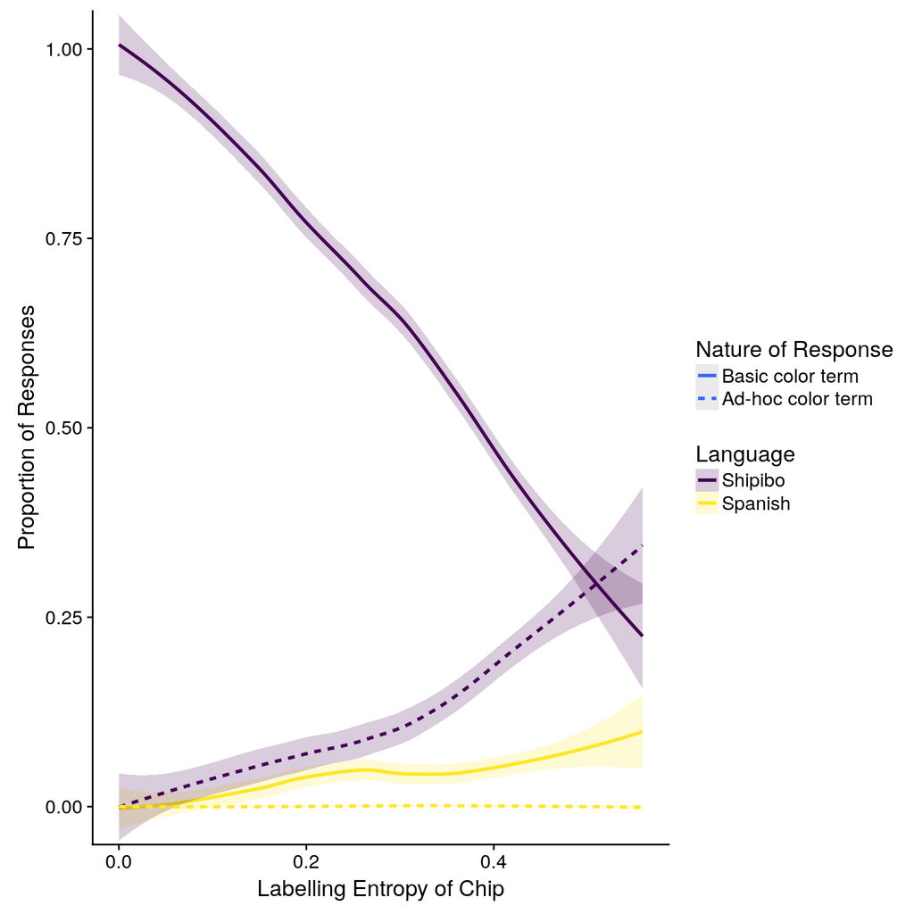

###Study 2

Results and Discussion

**Accuracy analyses and Spanish-language responses.**

Older children displayed a higher level of overall accuracy in comparison to younger children (*r*(55) = 0.544, *p* < 0.001, see Figure 2). Over a quarter (28%) of all responses were given in Spanish. The distribution of Spanish responses was non-random. There was no significant relationship between age and giving a response in a different language (*p* = 0.112 ). However, children tended to respond in Spanish when presented with a chip with low naming consensus (high entropy) among adult participants in Study 1. Even when accounting for between-subject differences and age, this effect remained strong (*p* = 0.003, see inset entropy values in Figure 2).

**Overextensions.**

The relationship between word entropy and language switching brings up the possibility that children may be using alternative strategies when they lack knowledge of the proper color term mapping. Participants might respond in Spanish if they fail to recall the proper SK color term but do know the proper mapping in the Spanish color system such as labeling a *panshin* chip as “amarillo”. They may also choose to respond with a same-language but adjacent color term such as “joshin” for a *panshin*-colored chip. If we allow for more leniency in scoring—accepting same-language, adjacent or different-language, corresponding responses—we can check for more subtlety surrounding color term mapping. Using a mixed-effects model, we found a significant improvement in accuracy scores when we allowed different-language but corresponding responses (*p* < 0.001) but no significant change when allowing for same-language but adjacent responses (*p* = 0.454).

## Study 3

Results and Discussion.

**Overextensions.**

Similar to Study 2, we adopted alternative scoring to accommodate language-switching from Spanish to Shipibo-Konibo and same-language adjacent responses. Using a mixed-effects model, we did not find that age explained a significant amount of the variation seen in accuracy (*p* = 0.124), in concordance with earlier analyses. However, we did find that participants made use of both mapping strategies of either providing different-language but corresponding responses (*p* < 0.001) or same-language but adjacent responses (*p* = 0.002). Between Studies 2 and 3, we find frequent use of language switching but only Study 3 shows significant use of same-language but adjacent terms as well. This discrepancy, along with the lack of an age correlation, can be due to foreign language exposure. Children may be exposed to Spanish at a young age but do not receive any formal Spanish education until later in adolescence. With a limited knowledge of Spanish color terms, children may spontaneously provide Spanish color terms during the Shipibo-language Study 2 but may struggle to succeed during Spanish-language Study 3. This suggests that children may rely on either strategy to communicate a color label to the best of their knowledge set.

**Comparisons between Studies 2 & 3. - Unfinished plots**

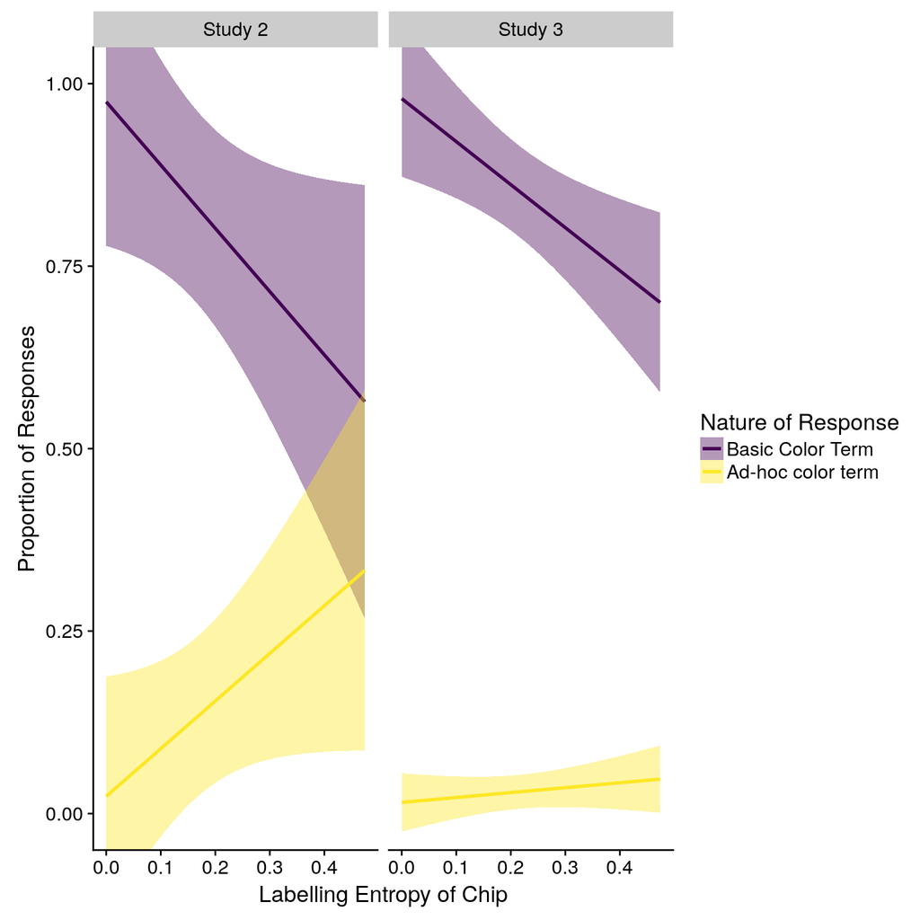

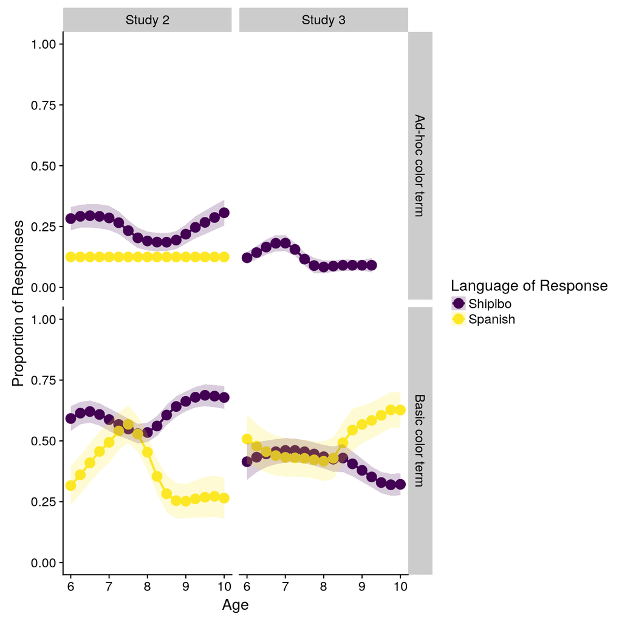

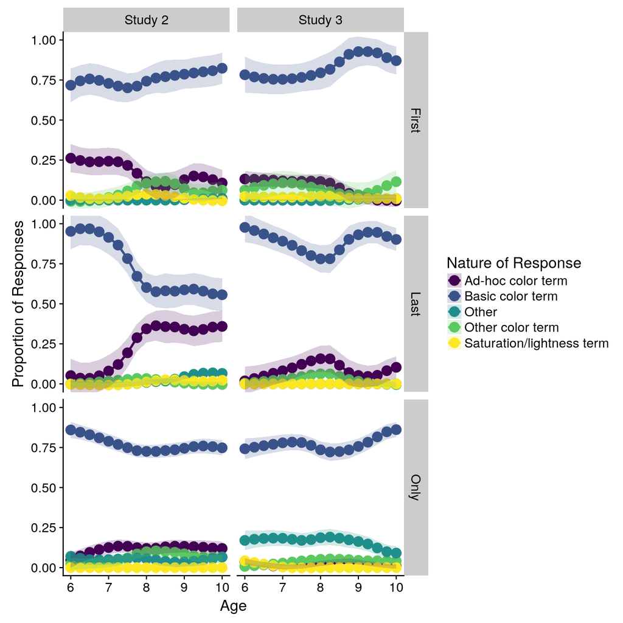

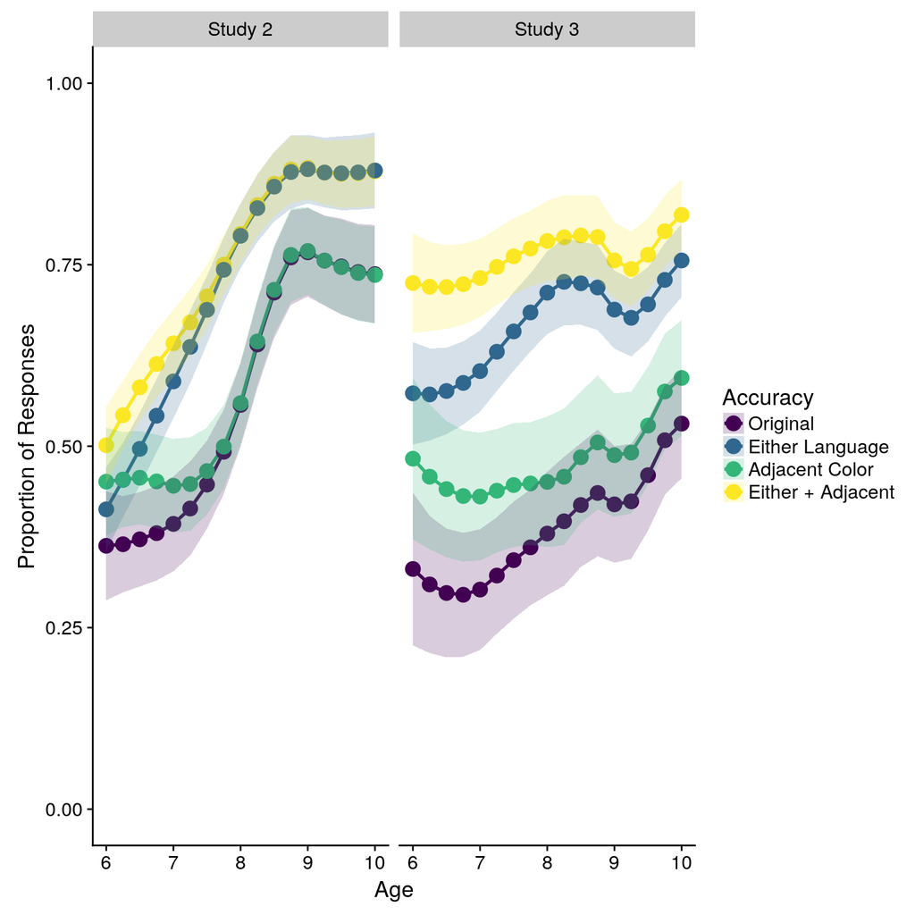

================================================

## Figures

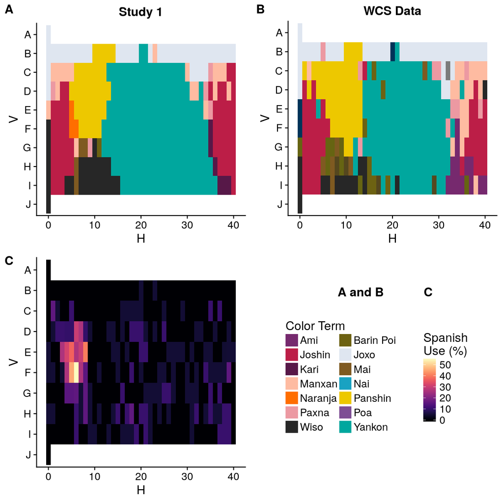

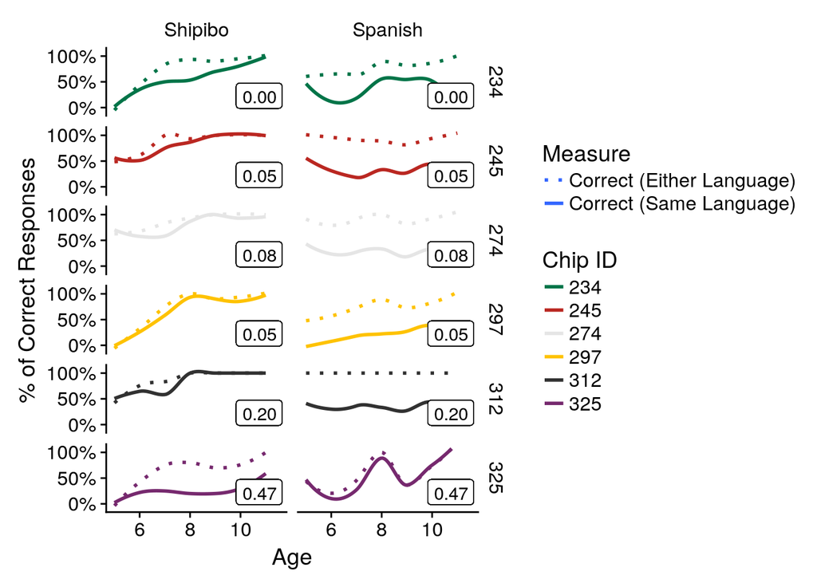

*Figure 2*. A comparison of children’s performance during the production task in Studies 2 and 3. Solid or dotted lines represent overall performance by age for a particular chip. Solid lines show whether the child gave a correct answer in the language indicated in that column; dotted lines show if they gave a response that was correct in either language. Line colors are representative of the chip’s color coordinates. Values in the lower-right corners of each subplot display the entropy (uncertainty) values calculated from adult responses given during Study 1.